# HDStIM

Rohit Farmer

2022-06-23

The primary function `HDStIM()` in the `HDStIM` package follows a heuristic approach to group cells into responding and non-responding. For a combination of cell population and stimulation type (e.g., CD127+ T-helper cells and interferon-alpha), `HDStIM()` starts by performing K-means clustering on the combined set of cells from stimulated and unstimulated samples. K-means clustering is performed on combined expression data of all the state (signaling/intracellular) markers. Upon clustering using a contingency table as shown below, a Fisher’s exact test determines the effect size and the statistical significance of partitioning. Cells from the combinations that pass the Fisher’s exact test (p-value < 0.05) are considered responding. An optional UMAP can also be calculated to visually verify the cell partitioning in responding and non-responding groups by using auxiliary plotting scripts provided in the package.

In addition to an auxiliary script to plot UMAPs, the package also comes with two other plotting scripts for K-means clustering and Fisher’s exact test and state marker density before and after mapping.

**An example of the contingency table used for Fisher’s exact test.**

```r
matrix(c(60, 40, 20, 80),nrow = 2, ncol = 2,
       dimnames = list(c("Cluster1", "Cluster2"), c("Stim", "Unstim")))
```

```
#>          Stim Unstim
#> Cluster1   60     20
#> Cluster2   40     80
```

# To Run The Main HDStIM Function

As stated above, `HDStIM()` is the primary function of the `HDStIM` package. We will use the example data set `chi11` (from mass cytometry) included in the package.

*Note:`chi11` is a minimal dataset included for unit testing only. Therefore, it does not represent a typical mass/flow cytometry assay.*

```r
library(HDStIM)

mapped_data <-  HDStIM(chi11$expr_data, chi11$state_markers,
                       chi11$cluster_col, chi11$stim_label,
                       chi11$unstim_label, seed_val = 123,
                       umap = TRUE, umap_cells = 500,
                       verbose = FALSE)

class(mapped_data)
```

```
#> [1] "list"
```

```r
attributes(mapped_data)
```

```
#> $names
#>  [1] "response_mapping_main" "stacked_bar_plot_data" "state_markers"
#>  [4] "cellpop_col"           "stim_label"            "unstim_label"
#>  [7] "seed_val"              "all_fisher_p_val"      "all_k_means_data"
#> [10] "umap_plot_data"        "umap"                  "umap_cells"
```

## Output

`HDStIM()` returns a list with the mapped expression data, data to plot stacked bar plots to visualize the K-means and Fisher’s exact test results, and data to plot the optional UMAPs. The list also includes tables containing statistical information from K-means and Fisher’s exact test and other information passed as the function attributes.

```r
head(mapped_data$response_mapping_main)
```

```
#> # A tibble: 6 × 41
#>   cluster_id sample_id      condition patient_id stim_type cell_population  CD45
#>        <dbl> <chr>          <chr>     <chr>      <chr>     <chr>           <dbl>
#> 1         79 CHI-011_1_2_G  CHI       CHI-011    G         CD11c CD14 CD38  3.48
#> 2         69 CHI-011_2_4_G  CHI       CHI-011    G         CD11c CD14 CD38  2.22
#> 3         69 CHI-011_4_13_G CHI       CHI-011    G         CD11c CD14 CD38  3.03
#> 4         79 CHI-011_4_11_G CHI       CHI-011    G         CD11c CD14 CD38  2.82
#> 5         69 CHI-011_2_5_G  CHI       CHI-011    G         CD11c CD14 CD38  2.07
#> 6         69 CHI-011_1_1_G  CHI       CHI-011    G         CD11c CD14 CD38  3.39
#> # … with 34 more variables: CD7 <dbl>, CD19 <dbl>, pPLCg2 <dbl>, CD4 <dbl>,
#> #   IgD <dbl>, CD20 <dbl>, CD25 <dbl>, pSTAT5 <dbl>, CD123 <dbl>, AKT <dbl>,
#> #   pSTAT1 <dbl>, CD27 <dbl>, pP38 <dbl>, CD24 <dbl>, pSTAT3 <dbl>,
#> #   CD11c <dbl>, CD14 <dbl>, CD56 <dbl>, IkBa <dbl>, pCREB <dbl>, CD16 <dbl>,
#> #   CD38 <dbl>, CD8 <dbl>, CD45RA <dbl>, CD3 <dbl>, pERK1_2 <dbl>,
#> #   HLA_DR <dbl>, pS6 <dbl>, CD127 <dbl>, ncount <int>, k_cluster_id <int>,
#> #   responding_cluster <int>, response_status <chr>, comb_no <int>
```

```r
head(mapped_data$stacked_bar_plot_data)
```

```
#> # A tibble: 6 × 7
#>   cell_population            stim_type  f_p_val stim_clust stim_status k_cluster
#>   <chr>                      <chr>        <dbl>      <dbl> <chr>       <chr>
#> 1 CD11c CD14 CD38            A         3.05e-26          1 unstim      cluster1
#> 2 CD11c CD14 CD38            A         3.05e-26          1 unstim      cluster2
#> 3 CD11c CD14 CD38            A         3.05e-26          1 stim        cluster1
#> 4 CD11c CD14 CD38            A         3.05e-26          1 stim        cluster2
#> 5 CD19 CD20 CD45RA HLA-DR C… A         5.56e-18          2 unstim      cluster1
#> 6 CD19 CD20 CD45RA HLA-DR C… A         5.56e-18          2 unstim      cluster2
#> # … with 1 more variable: cell_count_perc <dbl>
```

```r
head(mapped_data$umap_plot_data)
```

```
#> # A tibble: 6 × 8
#>   cell_population stim_type condition tot_of_cells no_of_cells  UMAP1  UMAP2
#>   <chr>           <chr>     <chr>     <chr>        <chr>        <dbl>  <dbl>
#> 1 CD11c CD14 CD38 A         CHI       200          200          0.181  1.02
#> 2 CD11c CD14 CD38 A         CHI       200          200          1.71   1.31
#> 3 CD11c CD14 CD38 A         CHI       200          200         -1.69  -1.56
#> 4 CD11c CD14 CD38 A         CHI       200          200          0.813  0.706
#> 5 CD11c CD14 CD38 A         CHI       200          200          1.23   0.791
#> 6 CD11c CD14 CD38 A         CHI       200          200          0.357 -1.27
#> # … with 1 more variable: response_status <chr>
```

```r
head(mapped_data$all_fisher_p_val)
```

```
#>   stim_type              cell_population stim_clust1 stim_clust2 unstim_clust1
#> 1         A              CD11c CD14 CD38          83          17            11
#> 2         A                 CD11c HLA-DR          43          57            50
#> 3         A CD19 CD20 CD45RA HLA-DR CD24          23          77            83
#> 4         A               CD3 CD27 CD127          35          65            32
#> 5         A          CD3 CD4 CD27 CD45RA          34          66            42
#> 6         A               CD3 CD4 HLA-DR          37          63            39
#>   unstim_clust2    estimate      p.value    conf.low  conf.high
#> 1            89 38.31592946 3.052288e-26 16.41025641 97.9574110
#> 2            50  0.75546384 3.950464e-01  0.41598165  1.3672058
#> 3            17  0.06232828 5.555794e-18  0.02850666  0.1296101
#> 4            68  1.14345766 7.645958e-01  0.60968684  2.1500051
#> 5            58  0.71262870 3.078444e-01  0.38474999  1.3129671
#> 6            61  0.91899062 8.842353e-01  0.49842428  1.6921035
#>                               method alternative      f_p_adj
#> 1 Fisher's Exact Test for Count Data   two.sided 2.441830e-25
#> 2 Fisher's Exact Test for Count Data   two.sided 7.023047e-01
#> 3 Fisher's Exact Test for Count Data   two.sided 2.539791e-17
#> 4 Fisher's Exact Test for Count Data   two.sided 9.212285e-01
#> 5 Fisher's Exact Test for Count Data   two.sided 6.156888e-01
#> 6 Fisher's Exact Test for Count Data   two.sided 9.781822e-01
```

```r
head(mapped_data$all_k_means_data)
```

```
#>   stim_type              cell_population    pPLCg2    pSTAT5        AKT
#> 1         A              CD11c CD14 CD38 0.6036923 1.5150197 0.19882950
#> 2         A              CD11c CD14 CD38 0.3433208 0.5100987 0.14467489
#> 3         A                 CD11c HLA-DR 0.2754466 0.2628448 0.08187613
#> 4         A                 CD11c HLA-DR 0.9878153 0.5947371 0.10871637
#> 5         A CD19 CD20 CD45RA HLA-DR CD24 0.2804838 0.2853633 0.07871608
#> 6         A CD19 CD20 CD45RA HLA-DR CD24 0.3600085 1.9650785 0.12718000
#>       pSTAT1       pP38    pSTAT3      IkBa    pCREB    pERK1_2        pS6 size
#> 1 2.46662032 0.85286553 1.4007937 1.8315034 2.752456 0.10329694 0.27964780   94
#> 2 0.80050991 0.69575908 0.2100968 1.4439438 2.346255 0.04306572 0.16080807  106
#> 3 0.09136274 0.03271188 0.0532651 0.8501084 0.437598 0.03960397 0.07132055   93
#> 4 0.65155894 0.13219535 0.2322881 2.4118800 2.118350 0.02017302 0.12388073  107
#> 5 0.51540424 0.12034285 0.1396368 2.7656495 1.401279 0.13669583 0.10065605  106
#> 6 1.79297154 0.21265052 0.7480344 3.1434614 1.702514 0.20580153 0.18568148   94
#>   withinss cluster
#> 1 342.6724       1
#> 2 340.0997       2
#> 3 174.5916       1
#> 4 266.5471       2
#> 5 255.0538       1
#> 6 236.2004       2
```

# To Plot Diagnostic Figures

## Plots Explaining K-means Clustering And Fisher’s Exact Test

Using the `stacked_bar_plot_data`, `plot_K_Fisher()` generates bar plots showing the percentage of cells from the stimulated and unstimulated samples clustered in the two K-means clusters a given cell population and stimulation type.

`plot_K_Fisher()` returns a list of ggplot objects. If the path is specified, it can also render and save the plots in PNG format.

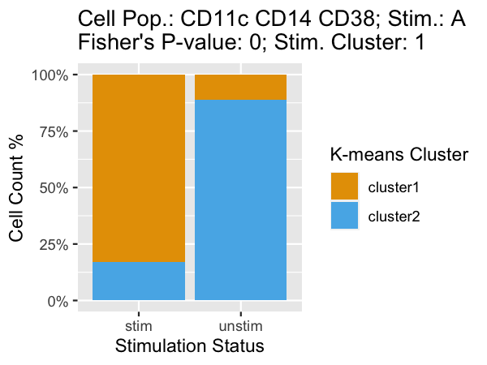

```r
k_plots <- plot_K_Fisher(mapped_data, path = NULL, verbose = FALSE)
k_plots[[1]]
```

## UMAP Plots To Visually Inspect Responding and Non-Responding Cell Mapping

*Note: You can only generate these plots if you have asked UMAPs to be calculated in the `HDStIM()` function.*

UMAP plots can be helpful for visually inspecting how well `HDStIM()` has mapped responding vs. non-responding cells for a cell population and stimulation type. `plot_umap()` also returns a list of ggplot objects and if the path is specified, it will render and save the plots in PNG format.

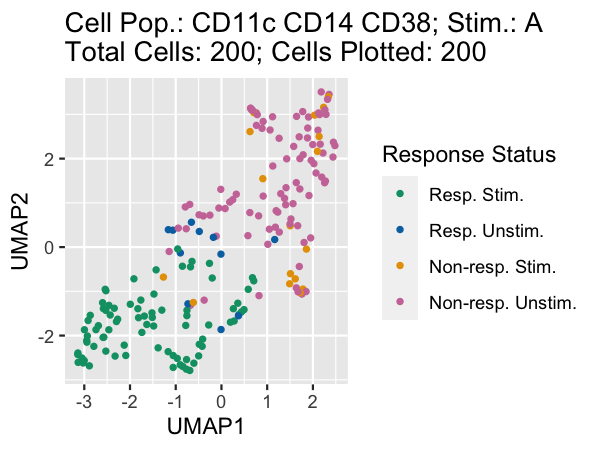

```r
u_plots <- plot_umap(mapped_data, path = NULL, verbose = FALSE)
u_plots[[1]]
```

## Distribution Plots for Individual State Marker before And After Mapping

For each state/signaling markers distribution plots shows the kernel density estimation of the pre `HDStIM()` data from both stimulated and unstimulated samples along with the density from cells from stimulated samples mapped as responding. `plot_exprs()` also returns a list of ggplot objects and if the path is specified, it will render and save the plots in PNG format.

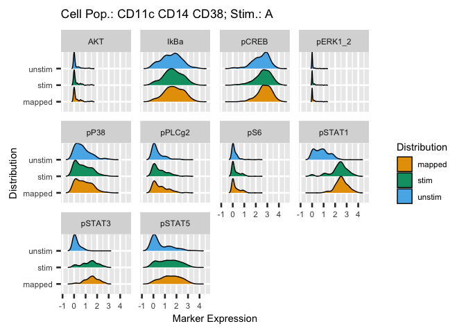

```r
e_plots <- plot_exprs(mapped_data, path = NULL,verbose = FALSE)
library(ggplot2)
e_plots[[1]] +
    theme(text = element_text(size = 11))
```

# To Rank State/Signaling Markers According To Their Contribution To The Response

`marker_ranking_boruta()` function runs Boruta on the stimulation - cell population combinations that passed the Fisher’s exact test to rank the markers according to their contribution to the response. The function returns a list with a tibble containing attribute statistics calculated by Boruta and ggplot objects. If the path is not NULL, plots are also rendered and saved in the specified folder in PNG format.

```r
m_ranks <- marker_ranking_boruta(mapped_data, path = NULL, n_cells = NULL,
                                 max_runs = 100, seed_val = 123,
                                 verbose = FALSE)

head(m_ranks$attribute_stats)
```

```
#> # A tibble: 6 × 9
#>   stim_type cell_population state_marker meanImp medianImp   minImp maxImp
#>   <chr>     <chr>           <fct>          <dbl>     <dbl>    <dbl>  <dbl>
#> 1 A         CD11c CD14 CD38 AKT           -0.366   -0.519  -1.70      1.62
#> 2 A         CD11c CD14 CD38 pP38           0.259   -0.0535 -0.602     1.35
#> 3 A         CD11c CD14 CD38 pERK1_2        2.52     2.69    0.0838    4.29
#> 4 A         CD11c CD14 CD38 pS6            2.76     2.81   -0.00866   5.20
#> 5 A         CD11c CD14 CD38 pPLCg2         2.83     2.92    0.370     5.67
#> 6 A         CD11c CD14 CD38 pCREB          4.52     4.42    2.26      7.27
#> # … with 2 more variables: normHits <dbl>, decision <chr>
```

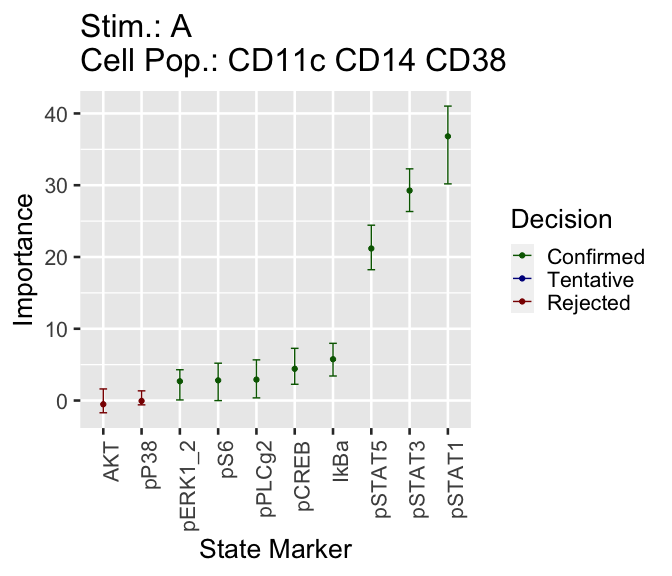

```r
m_ranks$plots[[1]]
```